# PROSPER LOAN DATASET

## INTRODUCTION

The following is an exploration of the Prosper Loan dataset.The data consists of information regarding 113,937 loans from ProsperLoans, including LoanStatus, BorrowerRate, and more information about loans. The dataset was sourced from https://s3.amazonaws.com/udacity-hosted-downloads/ud651/prosperLoanData.csv. Data dictionary from https://docs.google.com/spreadsheet/d/1gDyi_L4UvlrLTEC6Wri5nbaMmkGmLQBk-Yx3z0XDEtl/edit#gid=0

## Preliminary Wrangling

```python
import numpy as np
import pandas as pd
import matplotlib.pyplot as py
from matplotlib import rcParams
import seaborn as sb

%matplotlib inline

#display all columns in the dataset
pd.set_option("display.max_columns",None)
#set the precision for float columns
pd.options.display.float_format='{:,.1f}'.format
```

```python
loan_df=pd.read_csv("loan.csv")
```

```python
print(loan_df)
```

```
                     ListingKey  ListingNumber            ListingCreationDate  \
0       1021339766868145413AB3B         193129  2007-08-26 19:09:29.263000000
1       10273602499503308B223C1        1209647  2014-02-27 08:28:07.900000000
2       0EE9337825851032864889A          81716  2007-01-05 15:00:47.090000000
3       0EF5356002482715299901A         658116  2012-10-22 11:02:35.010000000
4       0F023589499656230C5E3E2         909464  2013-09-14 18:38:39.097000000
...                         ...            ...                            ...
113932  E6D9357655724827169606C         753087  2013-04-14 05:55:02.663000000
113933  E6DB353036033497292EE43         537216  2011-11-03 20:42:55.333000000
113934  E6E13596170052029692BB1        1069178  2013-12-13 05:49:12.703000000
113935  E6EB3531504622671970D9E         539056  2011-11-14 13:18:26.597000000
113936  E6ED3600409833199F711B7        1140093  2014-01-15 09:27:37.657000000

       CreditGrade  Term              LoanStatus           ClosedDate  \
0                C    36               Completed  2009-08-14 00:00:00
```

[output cut: 363 more lines]

```python
print(loan_df.shape)
```

```
(113937, 81)
```

```python
print(loan_df.info(verbose=True))
```

```
<class 'pandas.core.frame.DataFrame'>
RangeIndex: 113937 entries, 0 to 113936
Data columns (total 81 columns):
 #   Column                               Non-Null Count   Dtype
---  ------                               --------------   -----
 0   ListingKey                           113937 non-null  object
 1   ListingNumber                        113937 non-null  int64
 2   ListingCreationDate                  113937 non-null  object
 3   CreditGrade                          28953 non-null   object
 4   Term                                 113937 non-null  int64
 5   LoanStatus                           113937 non-null  object
 6   ClosedDate                           55089 non-null   object
 7   BorrowerAPR                          113912 non-null  float64
 8   BorrowerRate                         113937 non-null  float64
 9   LenderYield                          113937 non-null  float64
```

[output cut: 74 more lines]

### What is the structure of your dataset?

There are 113 937 loans in the dataset and 81 columns!Most of the columns appear to be numeric in nature.There are a number of columns that have several missing values.However,after consulting the data dictionary I quickly realised that most of these columns either only have scores for loans listed after July 2009 e.g ProsperScore or they hold conditional data. For instance TotalProsperLoans contains total number of Prosper loans the borrower has at the time they created this listing, however not every borrower has prior loans.Another thing I noted is that there are columns such as LoanStatus that are categorical but are recorded as objects.

### What is/are the main feature(s) of interest in your dataset?

Im most interested in figuring out which factors most affect the loan outcome status

Just some context: The loan outcome status is as follows:

Worst $\rightarrow$ best

Chargedoff $\rightarrow$ Defaulted$\rightarrow$Past Due(1-15 days)$\rightarrow$Past Due(16-30 days)$\rightarrow$Past Due(61-90 days)$\rightarrow$Past Due(91-120 days)$\rightarrow$Past Due(>120days$)\rightarrow$Cancelled$\rightarrow$Current$\rightarrow$FinalPaymentInProgress$\rightarrow$Completed

### What features in the dataset do you think will help support your investigation into your feature(s) of interest?

I assume that the following features affect the outcome status of a loan:

- BorrowerRate
- LoanOriginalAmount
- ProsperScore
- IncomeRange
- EmploymentStatus
- EmploymentStatusDuration
- Term
- ListingCategory (numeric)
- IsBorrowerHomeowner

### Data cleaning

Let me start off by creating a copy of the dataset that only contain features of interest

```python
loan=loan_df[["LoanStatus","BorrowerRate","LoanOriginalAmount","ProsperScore","IncomeRange","EmploymentStatus","EmploymentStatusDuration","Term","ListingCategory (numeric)","IsBorrowerHomeowner"]]
```

```python
print(loan.head(5))
```

```
  LoanStatus  BorrowerRate  LoanOriginalAmount  ProsperScore     IncomeRange  \
0  Completed           0.2                9425           NaN  $25,000-49,999
1    Current           0.1               10000           7.0  $50,000-74,999
2  Completed           0.3                3001           NaN   Not displayed
3    Current           0.1               10000           9.0  $25,000-49,999
4    Current           0.2               15000           4.0       $100,000+

  EmploymentStatus  EmploymentStatusDuration  Term  ListingCategory (numeric)  \
0    Self-employed                       2.0    36                          0
1         Employed                      44.0    36                          2
2    Not available                       NaN    36                          0
3         Employed                     113.0    36                         16
4         Employed                      44.0    36                          2

   IsBorrowerHomeowner
0                 True
1                False
2                False
3                 True
4                 True
```

```python
# Check for duplicated rows
sum(loan.duplicated())
```

```
2094
```

```python
#remove duplicated rows
loan=loan.drop_duplicates()
#check if removed successfully
sum(loan.duplicated())
```

```
0
```

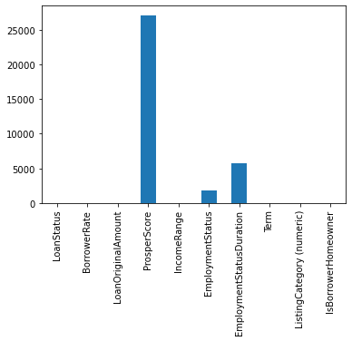

```python
#check for missing data
loan.isnull().sum().plot(kind='bar')
```

The 'missing' values in the ProsperScore are loans that were created before july 2009.I will not be removing those.

```python
#remove missing values in EmploymentStatus and EmploymentStatusDuration columns
columns_list=['EmploymentStatus','EmploymentStatusDuration']
for column in columns_list:
    loan=loan[loan[column].notnull()]

print(loan.isnull().sum())
```

```
LoanStatus                       0
BorrowerRate                     0
LoanOriginalAmount               0
ProsperScore                 21450
IncomeRange                      0
EmploymentStatus                 0
EmploymentStatusDuration         0
Term                             0
ListingCategory (numeric)        0
IsBorrowerHomeowner              0
dtype: int64
```

```python
loan.dtypes
```

```
LoanStatus                    object
BorrowerRate                 float64
LoanOriginalAmount             int64
ProsperScore                 float64
IncomeRange                   object
EmploymentStatus              object
EmploymentStatusDuration     float64
Term                           int64
ListingCategory (numeric)      int64
IsBorrowerHomeowner             bool
dtype: object
```

LoanStatus,ProsperScore,IncomeRange,EmploymentStatus and ListingCategory are all categorical columns and will be transformed as such.

LoanStatus,ProsperScore and IncomeRange are ordered so they will be transormed to reflect the ordering.

```python
#check the unique categories in each ordered column
print(loan['LoanStatus'].unique())
print(loan['ProsperScore'].unique())
print(loan['IncomeRange'].unique())
```

```
['Completed' 'Current' 'Past Due (1-15 days)' 'Defaulted' 'Chargedoff'
 'Past Due (16-30 days)' 'Past Due (61-90 days)' 'Past Due (31-60 days)'
 'Past Due (91-120 days)' 'FinalPaymentInProgress' 'Past Due (>120 days)'
 'Cancelled']
[nan  7.  9.  4. 10.  2. 11.  8.  5.  3.  6.  1.]
['$25,000-49,999' '$50,000-74,999' '$100,000+' '$75,000-99,999'
 '$1-24,999' 'Not employed' '$0' 'Not displayed']
```

```python
#replace all instances of $0,Not Displayed and Not employed to N/A
loan['IncomeRange'].replace(to_replace=['Not displayed','Not employed','$0'],
             value=['N/A','N/A','N/A'])
```

```
0         $25,000-49,999
1         $50,000-74,999
3         $25,000-49,999
4              $100,000+
5              $100,000+
               ...
113932    $50,000-74,999
113933    $75,000-99,999
113934    $25,000-49,999
113935    $25,000-49,999
113936    $50,000-74,999
Name: IncomeRange, Length: 106107, dtype: object
```

```python
# convert Loan Status,ProsperScore and IncomeRange into ordered categorical types
categorical_dict = {'LoanStatus': ['Chargedoff','Defaulted','Past Due(1-15 days)','Past Due(16-30 days)','Past Due(61-90 days)','Past Due(91-120 days)','Past Due(>120 days)','Cancelled','Current','FinalPaymentInProgress','Completed'],
                    'ProsperScore':[1,2,3,4,5,6,7,8,9,10],
                    'IncomeRange':['N/A','$1-24,999','$25,000-49,999','$50,000-74,999','$75,000-99,999','$100,000+']


                   }

for value in categorical_dict:
    ordered_values = pd.api.types.CategoricalDtype(ordered = True,
                                                categories = categorical_dict[value])
    loan[value] = loan[value].astype(ordered_values)
```

```python
#convert the remaining non-ordered columns to category
for col in ["EmploymentStatus","ListingCategory (numeric)"]:
    loan[col]=loan[col].astype('category')
```

The categories in Listing Category are coded into numbers.I will convert them into their nominal equivalents as guided by the variables dictionary

```python
loan['ListingCategory (numeric)'].replace(to_replace=[0,1,2,3,4,5,6,7,8,9,10,11,12,13,14,15,16,17,18,19,20],
             value=['Not Available','Debt Consolidation','Home Improvement','Business','Personal Loan','Student Use','Auto','Other','Baby&Adoption','Boat','CosmeticProcedure','Engagement Ring','Green Loans','Household Expenses','Large Purchases','Medical/Dental','Motorcycle','RV','Taxes','Vacation','Wedding Loans'],inplace=True)
```

```python
#rename the column to just listingCategory
loan.rename(columns={'ListingCategory (numeric)':'ListingCategory'},inplace=True)
```

```python
loan.dtypes
```

```
LoanStatus                  category
BorrowerRate                 float64
LoanOriginalAmount             int64
ProsperScore                category
IncomeRange                 category
EmploymentStatus            category
EmploymentStatusDuration     float64
Term                           int64
ListingCategory               object
IsBorrowerHomeowner             bool
dtype: object
```

```python
loan.head()
```

|  | LoanStatus | BorrowerRate | LoanOriginalAmount | ProsperScore | IncomeRange | EmploymentStatus | EmploymentStatusDuration | Term | ListingCategory | IsBorrowerHomeowner |
| --- | --- | --- | --- | --- | --- | --- | --- | --- | --- | --- |
| 0 | Completed | 0.2 | 9425 | NaN | $25,000-49,999 | Self-employed | 2.0 | 36 | Not Available | True |
| 1 | Current | 0.1 | 10000 | 7 | $50,000-74,999 | Employed | 44.0 | 36 | Home Improvement | False |
| 3 | Current | 0.1 | 10000 | 9 | $25,000-49,999 | Employed | 113.0 | 36 | Motorcycle | True |
| 4 | Current | 0.2 | 15000 | 4 | $100,000+ | Employed | 44.0 | 36 | Home Improvement | True |
| 5 | Current | 0.1 | 15000 | 10 | $100,000+ | Employed | 82.0 | 60 | Debt Consolidation | True |

Lastly I want to convert interest rate into a percentage

```python
loan['BorrowerRate']=loan['BorrowerRate']*100
```

## Univariate Exploration

I figure that I will mostly use histograms,vertical and horizontal bars for univariate exporation so I will write functions for creating those plots which I will call whenever I need them.

```python
#Function for creating Horizontal bar graph.The parameters:
# df =the dataframe
# ycolumn=the column whose values the plot will be based on
# color_index=the prefered color of the bars
# isSorted= boolean representing whether the values will be sorted or not

def makeHBar(df,ycolumn,color_index,isSorted):
    rcParams['figure.figsize'] = 12,6
    # Returns the sum of all not-null values in y column
    total_count = df[ycolumn].value_counts().sum()
    category_counts = df[ycolumn].value_counts(sort=isSorted)
    # Get the unique values of the `type` column, in the decreasing order of the frequency.
    category_order = category_counts.index

    base_color = sb.color_palette()[color_index]
    sb.countplot(data=df, y=ycolumn, color=base_color, order=category_order);
    # Logic to print the proportion text on the bars
    for i in range (category_counts.shape[0]):
        count = category_counts[i]
        # Convert count into a percentage, and then into string
        pct_string = '{:.1%}'.format(count/total_count)
        # Print the string value on the bar.
        py.text(count+1, i, pct_string, va='center')
```

```python
#Function for plotting histogram.The parameters:
# df=dataframe
# prefsize= the bin size
# xcolumn= the column whose values the plot is based on
# xlable=The lable of the x axis

def makeHistogram(df,prefsize,xcolumn,xLabel):
    binsize = prefsize
    bins = np.arange(0,df[xcolumn].max()+binsize, binsize)
    py.figure(figsize=[10, 5])
    py.hist(data = df, x = xcolumn,bins = bins)
    py.xlabel(xLabel)
    py.show()
```

```python
#### Function for creating Vertical bar graph.The parameters:
# df =the dataframe
# xcolumn=the column whose values the plot will be based on
# color_index=the prefered color of the bars
# isSorted= boolean representing whether the values will be sorted or not
# ticks_rotation= the angle at which the label ticks will be rotated

def makeVBar(df,xcolumn,isSorted,color_index,ticks_rotation):
    rcParams['figure.figsize'] = 12,6;
    total=df[xcolumn].value_counts().sum()
    category_counts = loan[xcolumn].value_counts(sort=isSorted)
    # Get the unique values of the `type` column, in the decreasing order of the frequency.
    category_order = category_counts.index
    base_color = sb.color_palette()[color_index]

    ax=sb.countplot(data=df, x=xcolumn, color=base_color,order=category_order);
    rects=ax.patches
    py.xticks(rotation=ticks_rotation);
    py.figure(figsize=(12,6))
    #for annotating the bars with percentages
    labels=['{:.1%}'.format(i/total) for i in category_counts]
    for rect,label in zip(rects,labels):
        height=rect.get_height()
        ax.text(rect.get_x()+rect.get_width()/2,height+5,label,ha="center",va="bottom")
```

```python
#Function for creating Pie chart.The parameters:
# df =the dataframe
# plot_column=the column whose values the plot will be based on

def makepie(df,plot_column):
    sorted_counts = df[plot_column].value_counts()
    py.pie(sorted_counts,labels=sorted_counts.index , startangle = 90, counterclock = False,autopct='%.1f%%');
    py.axis('square')
```

**1. What is the distribution of the loan status ?**

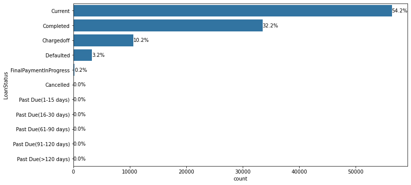

```python
makeHBar(loan,'LoanStatus',0,True)
```

**Observations**

**2. What is the distribution of interest rate/borrower rate?**

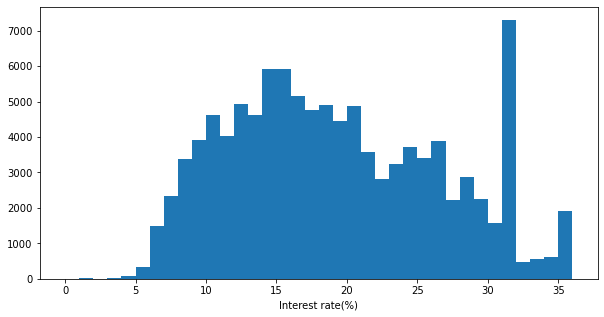

```python
makeHistogram(loan,1,'BorrowerRate','Interest rate(%)')
```

**Observations**

**3. What is the distribution of loan original amount?**

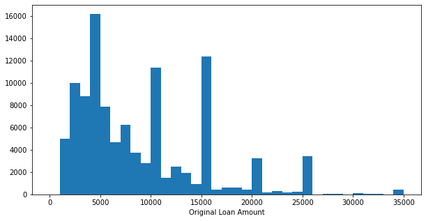

```python
makeHistogram(loan,1000,'LoanOriginalAmount','Original Loan Amount')
```

**Observations**

The data is multimodal.The peaks are found at 5000,10000,15000,20000,25000,30000,35000.This possibly reflects the main categories into which the loans are listed under.

**4. The distribution of Prosper Score?**

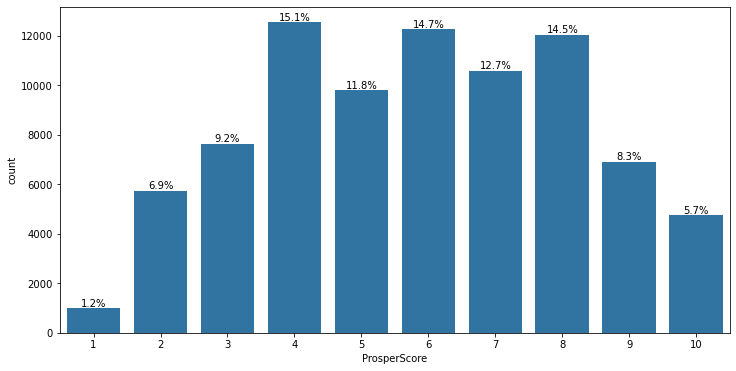

```python
makeVBar(loan,'ProsperScore',False,0,0)
```

**Observations**

The plot shows that the most common Prosper score is 4.However those who have a score of 6 and 8 are almost the equal to the number of borrowers with a score of 4.To get a more informative picture let us split the scores into three groups i.e lowscore:=<4 ;midscore:5-7 and highscore:8+

```python
lowscore=len(loan.query('ProsperScore<=4'))
midscore=len(loan.query('4<ProsperScore<8'))
highscore=len(loan.query('ProsperScore>=8'))
```

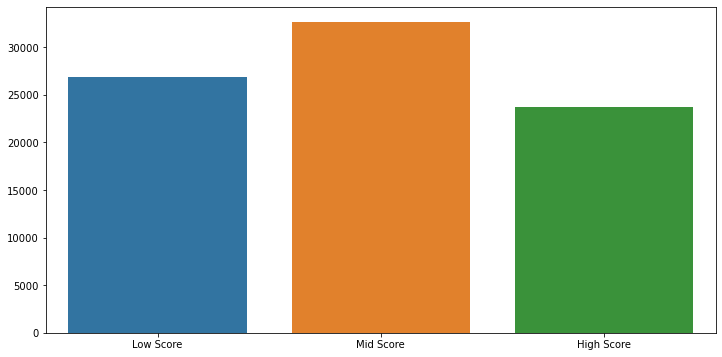

```python
yValues=[lowscore,midscore,highscore]
xValues=['Low Score','Mid Score','High Score']
sb.barplot(x = xValues,y=yValues,orient="v")
```

**Observations**

The simple plot highlights that most borrowers generally have moderate prosper scores between 5 and 7.Those who have high scores above 8 are in the minority

**5. What about the distribution of income ranges?**

```
posx and posy should be finite values
posx and posy should be finite values
```

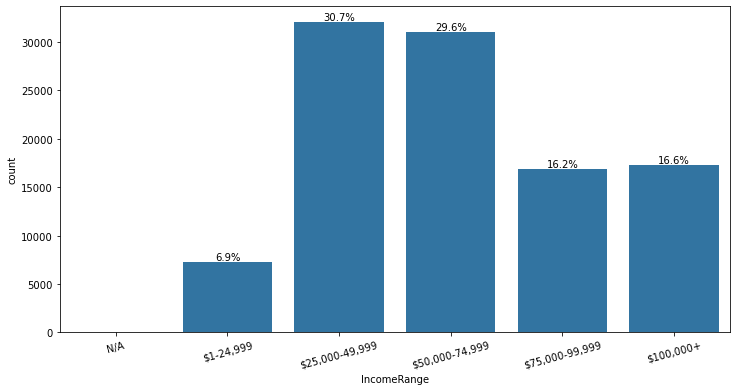

```python
makeVBar(loan,'IncomeRange',False,0,15)
```

**Observations**

Most borrowers earn between 25 000 to 75 000

**6. What does the employment status distribution look like?**

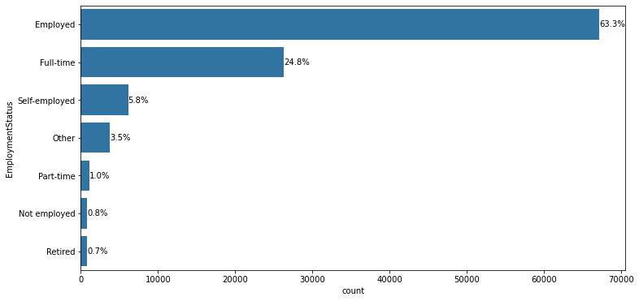

```python
makeHBar(loan,'EmploymentStatus',0,True)
```

**Observation**

Clearly, most of the borrowers are employed and a significant number of them are working full time

**7. What about the duration of those employment?**

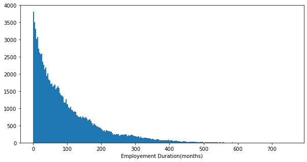

```python
makeHistogram(loan,3,'EmploymentStatusDuration','Employement Duration(months)')
```

**Observation**

There is a long tail in the data

**8.Whats the proportion of homeowners versus non-homeowners?**

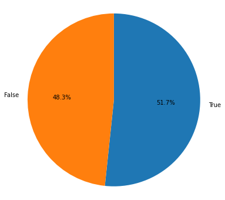

```python
makepie(loan,'IsBorrowerHomeowner')
```

**Observation**

There is not much difference between those who own homeowners and those who do not.This variable probably has little or no effect to our main point of interest i.e. loan outcome status

## Bivariate Exploration

**9. How do the numeric variables in the data correlate with each other?**

```python
numeric_variables = ['BorrowerRate', 'LoanOriginalAmount', 'EmploymentStatusDuration', 'Term']
```

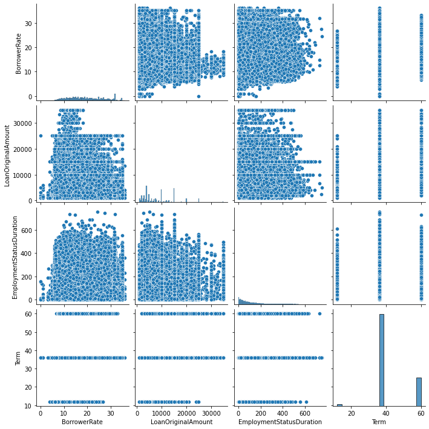

```python
sb.pairplot(loan,
             vars =numeric_variables ,
             kind = 'scatter');
```

Not very clear.Perhaps a better summary can come from a correlation heatmap.

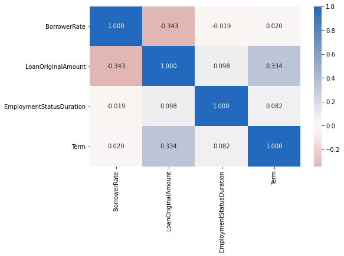

```python
# correlation plot
py.figure(figsize = [8, 5])
sb.heatmap(loan[numeric_variables].corr(), annot = True, fmt = '.3f',
           cmap = 'vlag_r', center = 0)
py.show()
```

**Observations**

Correlation results:

- Interest rate has weak negative correlation with loan amount. This implies that the lesser the amount one borrows the higher the interest rates they have to pay.Possibly a strategy for ProsperLoans to get people to borrow more money.
- Interest rate has a very weak negative correlation with employment status duration. The implication is that those who have been employed longer tend to pay lower interest rates.Perhaps those who have been employed longer tend to be perceived as a lesser risk.It would be intresting to check the relationship between employment status duration and ProsperScore which indicates the custom risk score of ProsperLoans.
- Interest rate has a weak positive correlation with the term of the loan. This suggests that the longer the term the higher the interest rate one attracts.Maybe a strategy for risk reduction here.The main risk here being losses due to inflation.
- Loan Amount has a moderate positive correlation with the term of the loan. The indication is that the more one borrows the longer the term they tend to take to pay it back.
- Loan Amount has a weak positive correlation with employment status duration. It is implied that those who have been employed for longer tend to ask for more money
- Lastly,employment status duration has a weak positive correlation with the term of the loan. The indication is that the longer one has been employed,the longer the term of the loan tends to be. Possibly because those who have been employed longer tend to borrow more as suggested by the positive correlation between loan amount and employment status duration.

**10. What is the relationship between our categorical values versus the numeric ones?**

```python
categoric_variables = ['LoanStatus','ProsperScore', 'IncomeRange', 'EmploymentStatus']
```

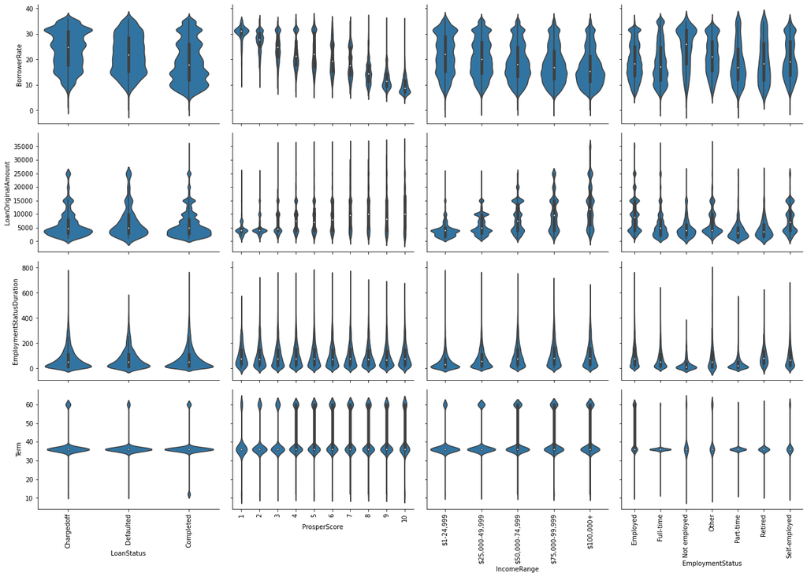

```python
def boxgrid(x, y, **kwargs):
    default_color = sb.color_palette()[0]
    sb.violinplot(x, y, color = default_color)

loanstatus = ['Chargedoff', 'Defaulted', 'Completed']
incomerange=['$1-24,999','$25,000-49,999','$50,000-74,999','$75,000-99,999','$100,000+']

loanstatuses = pd.api.types.CategoricalDtype(ordered=True, categories=loanstatus)
incomeranges= pd.api.types.CategoricalDtype(ordered=True, categories=incomerange)

loan['LoanStatus'] =loan['LoanStatus'].astype(loanstatuses);
loan['IncomeRange'] =loan['IncomeRange'].astype(incomeranges);

py.figure(figsize = [15, 20])

g = sb.PairGrid(data = loan, y_vars = numeric_variables, x_vars = categoric_variables,
               height = 3, aspect = 1.5)
for ax in g.axes.flatten():
    ax.set_xticklabels(ax.get_xticklabels(),rotation=90)



import warnings
warnings.filterwarnings("ignore")
g.map(boxgrid)
py.show();
```

**Observations**

1. LoanStatus

Key takeaway is that the median of intrest rates decreases noticeably from borrowers Chargedoff to those who completed.This strongly indicates that borrowers who managed to pay back their loans had lower interest rates than those who failed to do so.Moreover,the shape of the plot for borrowers who failed to pay back the loan widens as the intrest rate increases while for those who completed its the opposite.This reaffirms the abovementioned that borrowers who failed to pay back the loans had significantly higher interest rates than those who completed.Another noteworthy point is that when comparing Loanstatus and original loan amount,the plot for borrowers who completed payments has the highest max value indicating that borrowers in this category took out the largest amount than the other compared categories.

1. ProsperScore

It is clear that intrest rates decrease as the prosper score increases.This highlights that borrowers with the best scores have the least interest rates while those with poor scores attract more interest rates.In addition,loan amounts increase as the prosper score increases highlighting that those with better scores tend to borrow higher amounts than those with poor scores.Perhaps because intrest rates are not favorable to those with poor scores.

1. IncomeRange

**11. The relationship between the categorical variables?**

```
No handles with labels found to put in legend.
No handles with labels found to put in legend.
```

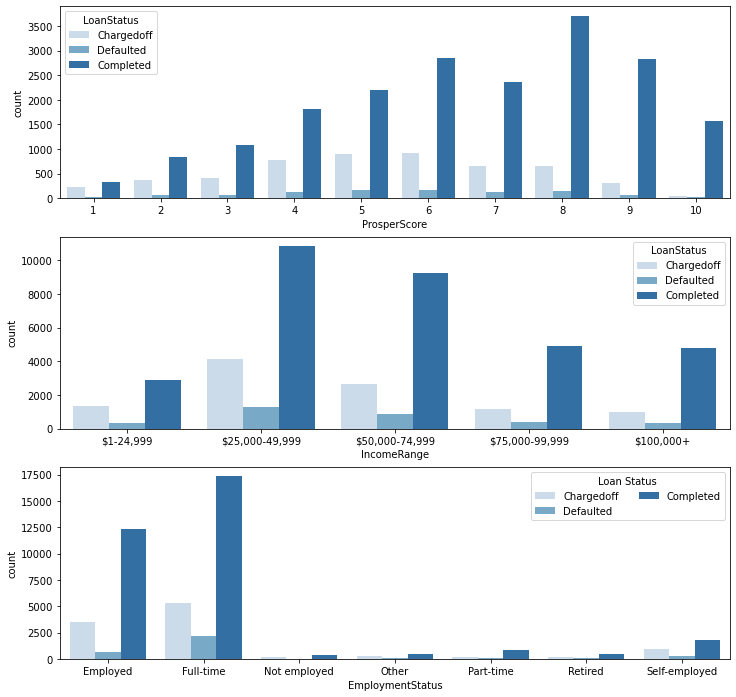

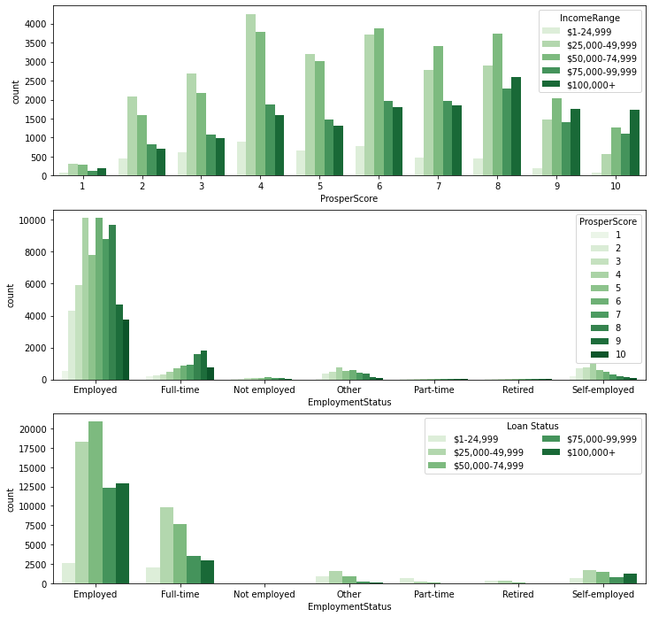

```python
py.figure(figsize = [12, 12])

# subplot 1: ProsperScore vs LoanStatus
py.subplot(3, 1, 1)
sb.countplot(data = loan, x = 'ProsperScore', hue = 'LoanStatus', palette = 'Blues')
ax.legend(ncol = 2,title='ProsperScore')

# subplot 2: IncomeRange vs LoanStatus
py.subplot(3, 1, 2)
sb.countplot(data = loan, x = 'IncomeRange', hue = 'LoanStatus', palette = 'Blues')
ax.legend(ncol = 2,title='ProsperScore')

# subplot 3: EmploymentStatus vs LoanStatus
ax = py.subplot(3, 1, 3)
sb.countplot(data = loan, x = 'EmploymentStatus', hue = 'LoanStatus', palette = 'Blues')
ax.legend(ncol = 2,title='Loan Status') # re-arrange legend to reduce overlapping



py.show()

py.figure(figsize = [12, 12])

# subplot 4: ProsperScore vs IncomeRange
py.subplot(3, 1, 1)
sb.countplot(data = loan, x = 'ProsperScore', hue = 'IncomeRange', palette = 'Greens')
ax.legend(ncol = 2,title='ProsperScore')

# subplot 5: EmploymentStatus vs ProsperScore
py.subplot(3, 1, 2)
sb.countplot(data = loan, x = 'EmploymentStatus', hue = 'ProsperScore', palette = 'Greens')
ax.legend(ncol = 2,title='ProsperScore')

# subplot 6: EmploymentStatus vs IncomeRange
ax = py.subplot(3, 1, 3)
sb.countplot(data = loan, x = 'EmploymentStatus', hue = 'IncomeRange', palette = 'Greens')
ax.legend(ncol = 2,title='Loan Status') # re-arrange legend to reduce overlapping



py.show()
```

**Observations**

1. Loan Status

Generally,frequency of borrowers who completed their payments increases as we move torwards the higher prosper scores.Most of those who completed have a score of 8.Most of those who either defaulted or got charged off have a score of 6 which quite surprised me.I expected the most common score would be much lower for these two groups.

1. Prosper Score

For those with a prosper score of 5 or less, the most common income range is below 50 000.Then from prosper score of 6 to 9 the most common range becomes 50 000 to about 75 000.Finally for borrowers with the best prosper score of 10, the most common range is 100 000 and over.So income ranges tend to increase with the increase in prosper scores.

### Talk about some of the relationships you observed in this part of the investigation. How did the feature(s) of interest vary with other features in the dataset?

Key takeaway is that median borrower rate/interest rate for borrowers who completed their loan payments is lower by almost 8 points compared to borrowers who failed to pay back the loan,suggesting that interest rate has a strong effect on the loan outcome status.I imagine that features that have a significant effect on interest rate will likely have an effect on the loan outcome status.These features are ProsperScore & IncomeRange and I will discuss the relationships among them below.

## Multivariate Exploration

As alluded to above, this part of the exploration will focus on investigating the relationships among intrest rate,prosper score and income range versus loan outcome status.

For this part,I have decided to melt down my categories into fewer ones that i feel better convey their meaning.

- The loan outcome will be categorized into two groups i.e. borrowers who managed to complete their loan payments and those that failed.
- Income range will be categorized into three ordered groups as so:low-income(earning less than 50,000); average-income(earning between 50,000 and 74,999) and high-income(earning over 75,000).
- ProsperScores will be categorized into three groups which are:low-scores(1-4);average-scores(5-6) and high-scores(7-10).

```python
def meltCategories():
    loan['ProsperScore'].replace(to_replace=[1,2,3,4,5,6,7,8,9,10],
    value=['lowscore','lowscore','lowscore','lowscore','avgscore','avgscore','highscore','highscore','highscore','highscore'],inplace=True)
    loan['LoanStatus'].replace(to_replace=["Chargedoff","Defaulted"],
    value=['failed-to-complete','failed-to-complete'],inplace=True)
    loan['IncomeRange'].replace(to_replace=['$1-24,999','$25,000-49,999','$50,000-74,999','$75,000-99,999','$100,000+'],
             value=['low-income','low-income','avg-income','high-income','high-income'],inplace=True)

    prosperscore = ['lowscore', 'avgscore', 'highscore']
    income_range=['low-income','avg-income','high-income']
    loan_status=['failed-to-complete','Completed']

    prosperscores = pd.api.types.CategoricalDtype(ordered=True, categories=prosperscore)
    incomeranges= pd.api.types.CategoricalDtype(ordered=True, categories=income_range)
    loanstats= pd.api.types.CategoricalDtype(ordered=True, categories=loan_status)

    loan['ProsperScore'] =loan['ProsperScore'].astype(prosperscores);
    loan['IncomeRange'] =loan['IncomeRange'].astype(incomeranges);
    loan['LoanStatus'] =loan['LoanStatus'].astype(loanstats);

meltCategories()
```

**12.What does the relationship between interest rate & Prosper versus loan outcome look like?**

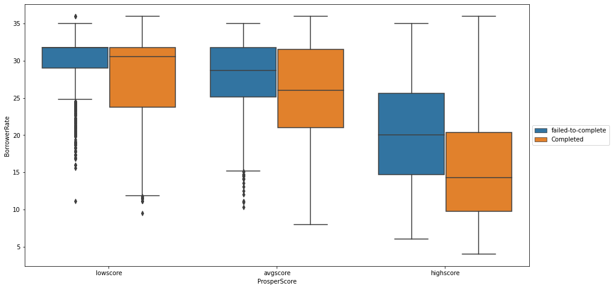

```python
fig = py.figure(figsize = [15,8])
sb.boxplot(data = loan, x = 'ProsperScore', y = 'BorrowerRate', hue = 'LoanStatus')
py.legend(loc = 6, bbox_to_anchor = (1.0, 0.5)) # legend to right of figure
py.xticks(rotation = 0)
py.show()
```

**Observations**

Key takeaways are that Intrest rates definitely decrease as prosper scores increase from lowscores to highscores and intrest rates for borrowers who completed their loan payments are always lower than for borrowers who failed to complete. Also, the gap in median intrest rates between those who completed and those who did not widens as we go from low prosper scores to high prosper scores.

**12. What about the relationship for incomerange & interest rate versus loan outcome?**

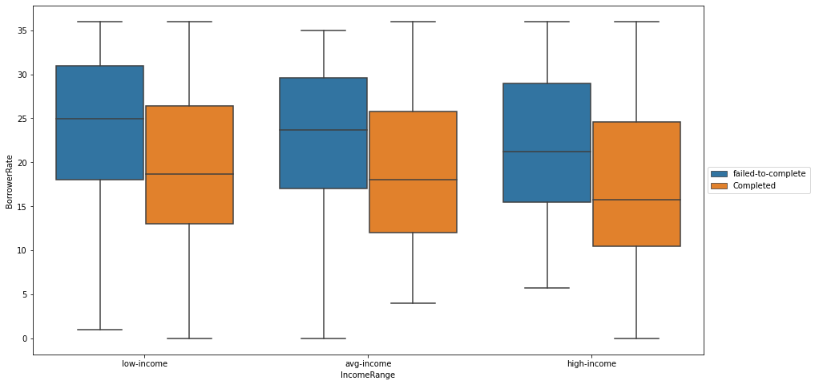

```python
fig = py.figure(figsize = [15,8])
sb.boxplot(data = loan, x = 'IncomeRange', y = 'BorrowerRate', hue = 'LoanStatus')
py.legend(loc = 6, bbox_to_anchor = (1.0, 0.5)) # legend to right of figure
py.xticks(rotation = 0)
py.show()
```

**Observations**

There isnt that much difference between intrest rates across different income ranges.It does reaffirm though,that interest rates for borrowers who completed their payments are significantly lower compared to those who did not.

**13. Lets check the relationship between ProsperScores & Income Range vs loan outcome status**

It was noted that Intrest rates definitely decrease as prosper scores increase from lowscores to highscores and interest rates for borrowers who completed their loan payments are always significantly lower than for borrowers who failed to complete.Also, in the group who completed their payments,the number of borrowers who have high prosper scores is almost double of those who have average scores and more than double of those with low scores. In the group that failed to make their payments however,borrowers that have high prosper scores are the least.Most in this group have average scores but closely followed by lowscores.

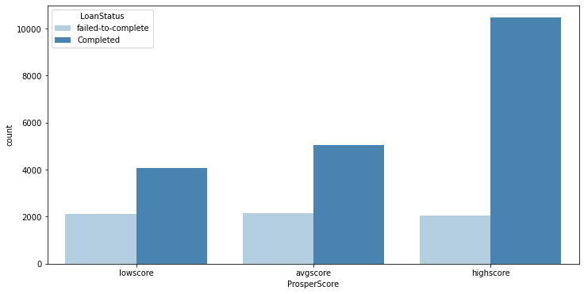

```python
sb.countplot(data = loan, x = 'ProsperScore', hue = 'LoanStatus', palette = 'Blues')
ax.legend(ncol = 2,title='ProsperScore')
```

```python
#Borrowers who completed payment of their loans
completed=loan.query('LoanStatus=="Completed"')
```

```python
#Borrowers who failed to complete payment of their loans
failed=loan.query('LoanStatus=="failed-to-complete"')
```

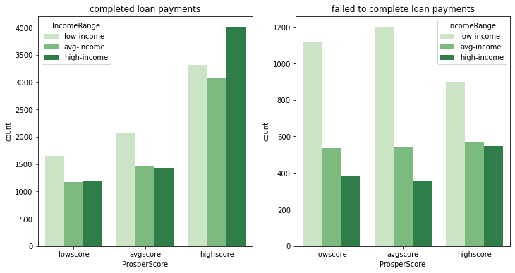

```python
# subplot 1: ProsperScore and IncomeRange vs Completed Loan payments
py.subplot(1, 2, 1)
sb.countplot(data = completed, x = 'ProsperScore', hue = 'IncomeRange', palette = 'Greens')
py.title('completed loan payments')
ax.legend(ncol = 2,title='ProsperScore')

# subplot 2: ProsperScore and IncomeRange vs failed Loan payments
py.subplot(1, 2, 2)
sb.countplot(data = failed, x = 'ProsperScore', hue = 'IncomeRange', palette = 'Greens')
py.title('failed to complete loan payments')
ax.legend(ncol = 2,title='ProsperScore')
```

```python
g=loan.query('ProsperScore=="highscore" & BorrowerRate<20')
```

```python
b=loan.query('ProsperScore=="lowscore" & BorrowerRate>20')
```

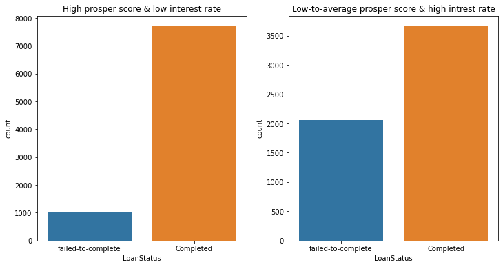

```python
# subplot 1: High prosper score & low interest rate
py.subplot(1, 2, 1)
sb.countplot(data = g, x = 'LoanStatus')
py.title('High prosper score & low interest rate')
ax.legend(ncol = 2,title='ProsperScore')

# subplot 1: Low-to-average prosper score & high intrest rate
py.subplot(1, 2, 2)
sb.countplot(data = b, x = 'LoanStatus')
py.title('Low-to-average prosper score & high intrest rate')
ax.legend(ncol = 2,title='ProsperScore')
```

**Observations**

Key takeaway is that in the group who completed their payments,the number of borrowers who have high prosper scores is almost double of those who have average scores and more than double of those with low scores. In the group that failed to make their payments however,borrowers that have high prosper scores are the least.Most in this group have average scores but closely followed by lowscores.